# Multiple Linear Regression Wine Model

# Simple Linear Regression

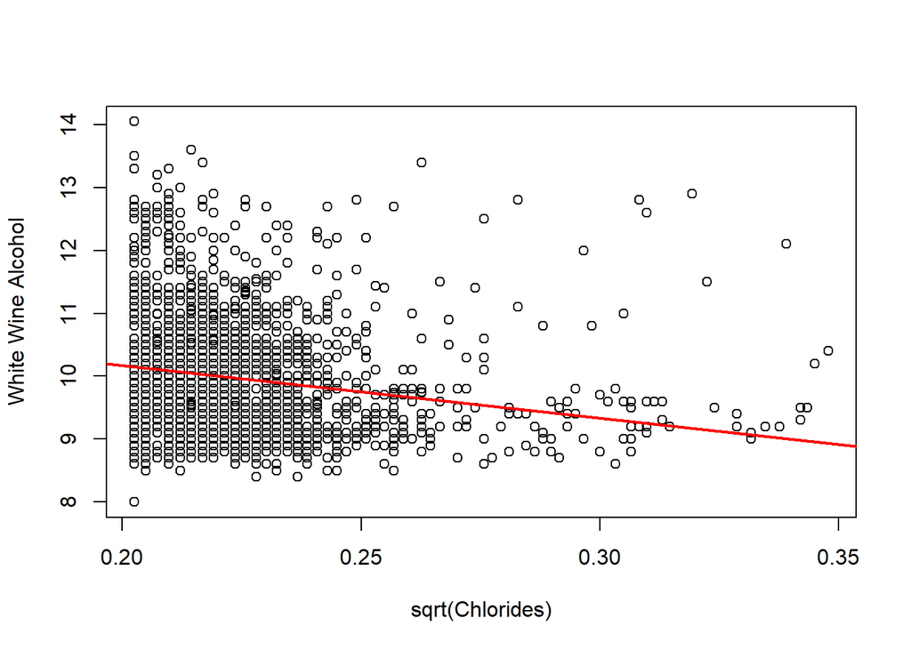

```
##
## Call:
## lm(formula = alcohol ~ chlorides, data = whitewine.filtered)
##
## Residuals:
##     Min      1Q  Median      3Q     Max
## -2.1476 -0.6901 -0.1803  0.5131  3.9024
##
## Coefficients:
##             Estimate Std. Error t value Pr(>|t|)
## (Intercept)  11.8372     0.1968  60.161   <2e-16 ***
## chlorides    -8.3442     0.8696  -9.595   <2e-16 ***
## ---
## Signif. codes:  0 '***' 0.001 '**' 0.01 '*' 0.05 '.' 0.1 ' ' 1
##
## Residual standard error: 0.9237 on 2547 degrees of freedom
## Multiple R-squared:  0.03489,    Adjusted R-squared:  0.03451
## F-statistic: 92.07 on 1 and 2547 DF,  p-value: < 2.2e-16
```

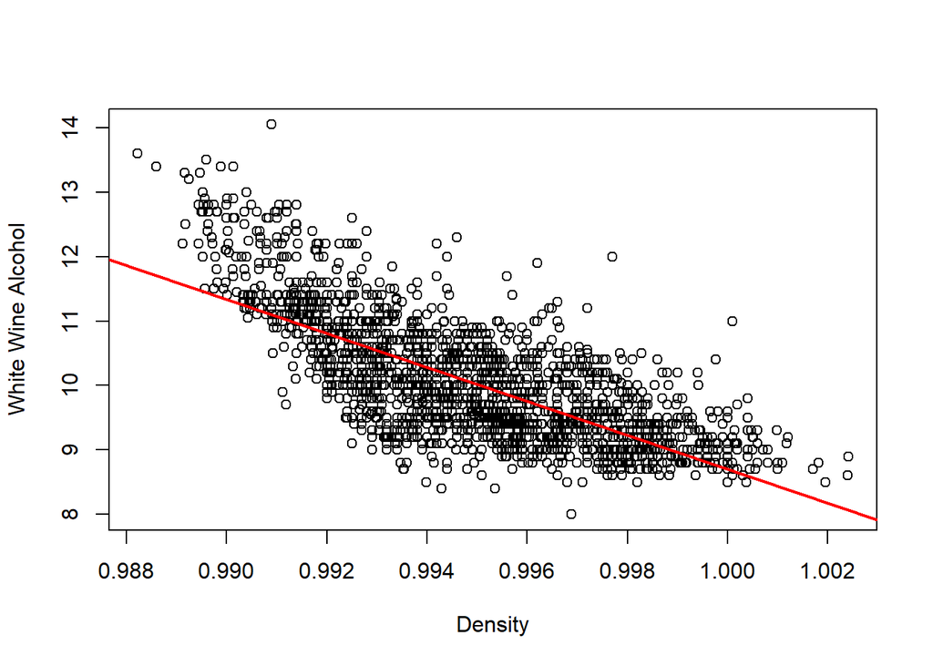

```
##
## Call:
## lm(formula = alcohol ~ density, data = whitewine.filtered)
##
## Residuals:
##      Min       1Q   Median       3Q      Max
## -1.80654 -0.42268 -0.02373  0.38639  2.94946
##
## Coefficients:
##             Estimate Std. Error t value Pr(>|t|)
## (Intercept)  272.415      4.678   58.23   <2e-16 ***
## density     -263.714      4.700  -56.10   <2e-16 ***
## ---
## Signif. codes:  0 '***' 0.001 '**' 0.01 '*' 0.05 '.' 0.1 ' ' 1
##
## Residual standard error: 0.6288 on 2547 degrees of freedom
## Multiple R-squared:  0.5527, Adjusted R-squared:  0.5526
## F-statistic:  3148 on 1 and 2547 DF,  p-value: < 2.2e-16
```

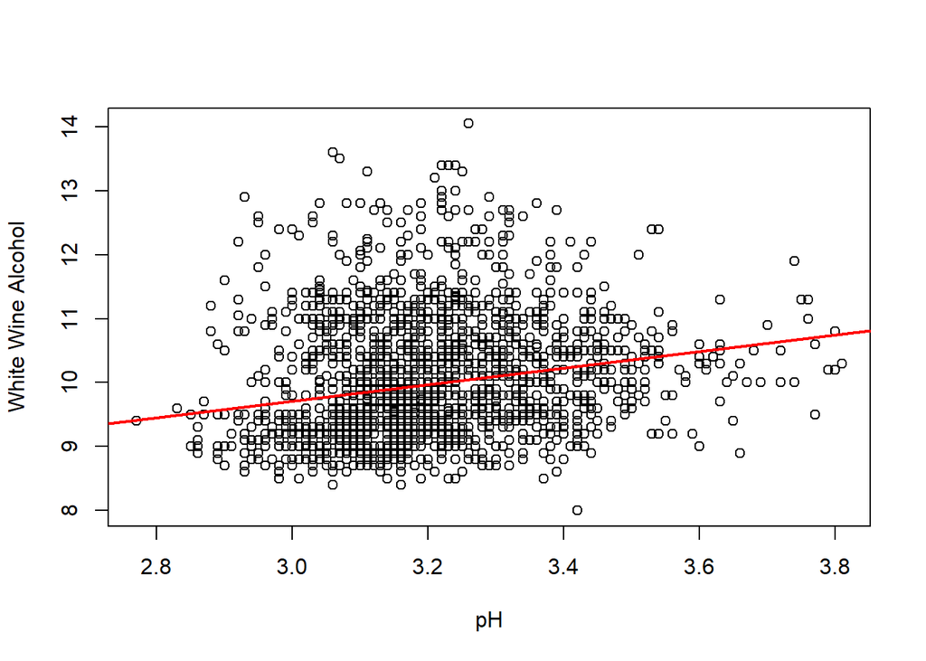

```
##
## Call:
## lm(formula = alcohol ~ pH, data = whitewine.filtered)
##
## Residuals:
##     Min      1Q  Median      3Q     Max
## -2.2522 -0.6651 -0.2260  0.4902  4.0045
##
## Coefficients:
##             Estimate Std. Error t value Pr(>|t|)
## (Intercept)   5.8359     0.3835   15.22   <2e-16 ***
## pH            1.2913     0.1200   10.76   <2e-16 ***
## ---
## Signif. codes:  0 '***' 0.001 '**' 0.01 '*' 0.05 '.' 0.1 ' ' 1
##
## Residual standard error: 0.9196 on 2547 degrees of freedom
## Multiple R-squared:  0.04348,    Adjusted R-squared:  0.0431
## F-statistic: 115.8 on 1 and 2547 DF,  p-value: < 2.2e-16
```

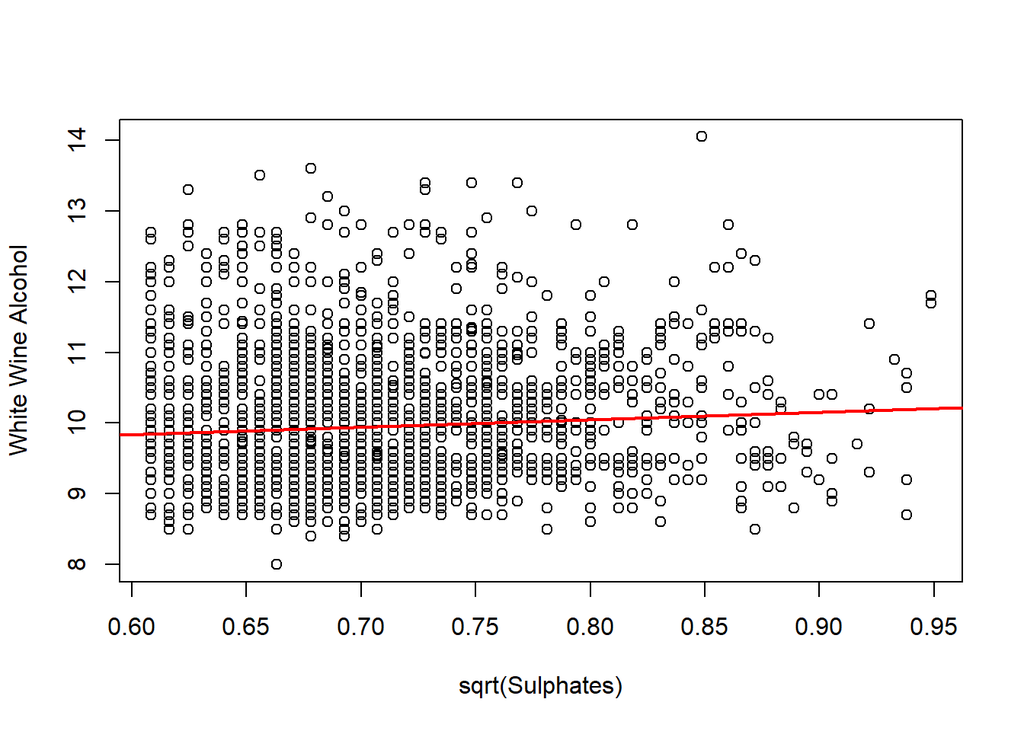

```
##
## Call:
## lm(formula = alcohol ~ sulphates, data = whitewine.filtered)
##
## Residuals:
##     Min      1Q  Median      3Q     Max
## -1.9091 -0.7091 -0.2268  0.5333  3.9451
##
## Coefficients:
##             Estimate Std. Error t value Pr(>|t|)
## (Intercept)   9.2081     0.2023   45.52  < 2e-16 ***
## sulphates     1.0569     0.2841    3.72 0.000204 ***
## ---
## Signif. codes:  0 '***' 0.001 '**' 0.01 '*' 0.05 '.' 0.1 ' ' 1
##
## Residual standard error: 0.9377 on 2547 degrees of freedom
## Multiple R-squared:  0.005404,   Adjusted R-squared:  0.005013
## F-statistic: 13.84 on 1 and 2547 DF,  p-value: 0.0002036
```

# Multiple Linear Regression

```r
#Multiple Regression (*using square root transformation filtered data)
whitewine.filtered.lm <- lm(alcohol ~ chlorides+density+pH+sulphates, data=whitewine.filtered)
summary(whitewine.filtered.lm)
```

```
##
## Call:
## lm(formula = alcohol ~ chlorides + density + pH + sulphates,
##     data = whitewine.filtered)
##
## Residuals:
##      Min       1Q   Median       3Q      Max
## -1.75288 -0.40214 -0.03374  0.35602  2.69409
##
## Coefficients:
##               Estimate Std. Error t value Pr(>|t|)
## (Intercept)  263.62684    4.65747  56.603  < 2e-16 ***
## chlorides     -3.34447    0.58271  -5.740 1.06e-08 ***
## density     -256.84352    4.66116 -55.103  < 2e-16 ***
## pH             0.57720    0.08167   7.067 2.03e-12 ***
## sulphates      1.21485    0.18816   6.457 1.28e-10 ***
## ---
## Signif. codes:  0 '***' 0.001 '**' 0.01 '*' 0.05 '.' 0.1 ' ' 1
##
## Residual standard error: 0.6112 on 2544 degrees of freedom
## Multiple R-squared:  0.578,  Adjusted R-squared:  0.5773
## F-statistic:   871 on 4 and 2544 DF,  p-value: < 2.2e-16
```

```r
#choose linear model
stepAIC(whitewine.filtered.lm,direction="both")
```

```
## Start:  AIC=-2505.11
## alcohol ~ chlorides + density + pH + sulphates
##
##             Df Sum of Sq     RSS      AIC
## <none>                    950.28 -2505.11
## - chlorides  1     12.30  962.58 -2474.31
## - sulphates  1     15.57  965.85 -2465.68
## - pH         1     18.66  968.93 -2457.55
## - density    1   1134.18 2084.45  -504.84
```

```
##
## Call:
## lm(formula = alcohol ~ chlorides + density + pH + sulphates,
##     data = whitewine.filtered)
##
## Coefficients:
## (Intercept)    chlorides      density           pH    sulphates
##    263.6268      -3.3445    -256.8435       0.5772       1.2149
```

```r
whitewine.final.lm <- lm(alcohol ~ chlorides+density+sulphates, data=whitewine.filtered)
summary(whitewine.final.lm)
```

```
##
## Call:
## lm(formula = alcohol ~ chlorides + density + sulphates, data = whitewine.filtered)
##
## Residuals:
##      Min       1Q   Median       3Q      Max
## -1.77140 -0.40919 -0.03438  0.36167  2.73846
##
## Coefficients:
##              Estimate Std. Error t value Pr(>|t|)
## (Intercept)  269.7618     4.6197  58.394  < 2e-16 ***
## chlorides     -3.5312     0.5877  -6.009 2.14e-09 ***
## density     -261.2672     4.6632 -56.028  < 2e-16 ***
## sulphates      1.4292     0.1875   7.624 3.45e-14 ***
## ---
## Signif. codes:  0 '***' 0.001 '**' 0.01 '*' 0.05 '.' 0.1 ' ' 1
##
## Residual standard error: 0.617 on 2545 degrees of freedom
## Multiple R-squared:  0.5697, Adjusted R-squared:  0.5692
## F-statistic:  1123 on 3 and 2545 DF,  p-value: < 2.2e-16
```

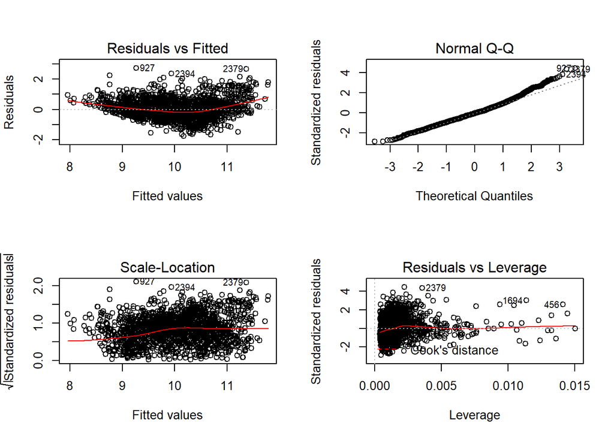

```r
par(mfrow=c(2,2))
plot(whitewine.final.lm)
```

```r
####Adjusted R-squared is highest for Square Root
# Transformation: Square Root -> Multiple R-squared:  0.5697,   Adjusted R-squared:  0.5692
# Transformation: Log (chloride and sulphate) -> Multiple R-squared:  0.448,    Adjusted R-squared:  0.4466
# Transformation: Log (all variables) -> Multiple R-squared:  0.4484,   Adjusted R-squared:  0.4471

#model coefficient confidence intervals
confint(whitewine.final.lm, conf.level=0.95)
```

```
##                   2.5 %     97.5 %
## (Intercept)  260.703128  278.82047
## chlorides     -4.683626   -2.37886
## density     -270.411159 -252.12324
## sulphates      1.061636    1.79686
```

# White Wine Predictions using Multiple Regression Model

```r
#Prediction 1: alcohol content of white wine using our white wine model (specific example with confidence interval or prediction interval)

## Predictions that work: Row 200: (9.9 for alcohol)
predict(whitewine.final.lm, data.frame(chlorides=0.2408319, sulphates=0.6403124, density=0.99500), level=.95, interval="confidence")
```

```
##        fit      lwr      upr
## 1 9.865663 9.827093 9.904234
```

```r
#       fit      lwr      upr
#  9.865663 9.827093 9.904234

## Predictions that don't work: Row 110: (9.4 for alcohol)
predict(whitewine.final.lm, data.frame(chlorides=0.2323790, sulphates=0.6244998, density=0.99720), level=.95, interval="confidence")
```

```
##        fit     lwr      upr
## 1 9.298125 9.25441 9.341839
```

```r
#       fit     lwr      upr
#   9.298125 9.25441 9.341839

summary(whitewine.final.lm)
```

```
##
## Call:
## lm(formula = alcohol ~ chlorides + density + sulphates, data = whitewine.filtered)
##
## Residuals:
##      Min       1Q   Median       3Q      Max
## -1.77140 -0.40919 -0.03438  0.36167  2.73846
##
## Coefficients:
##              Estimate Std. Error t value Pr(>|t|)
## (Intercept)  269.7618     4.6197  58.394  < 2e-16 ***
## chlorides     -3.5312     0.5877  -6.009 2.14e-09 ***
## density     -261.2672     4.6632 -56.028  < 2e-16 ***
## sulphates      1.4292     0.1875   7.624 3.45e-14 ***
## ---
## Signif. codes:  0 '***' 0.001 '**' 0.01 '*' 0.05 '.' 0.1 ' ' 1
##
## Residual standard error: 0.617 on 2545 degrees of freedom
## Multiple R-squared:  0.5697, Adjusted R-squared:  0.5692
## F-statistic:  1123 on 3 and 2545 DF,  p-value: < 2.2e-16
```

# Red Wine Predictions using Multiple Regression Model

```r
#Prediction 2: alcohol content of red wine using our white wine model (specific example with confidence interval or prediction interval)

redwine_raw <- read.table("winequality-red.csv", sep=";", header=TRUE)

myvars <- c("chlorides","sulphates","density","pH","alcohol")
redwine <- redwine_raw[myvars]
redwine[1:2] <- sqrt(redwine[1:2])
redwine.filtered <- redwine %>%
  filter(chlorides>0.2, sulphates>0.6) %>%
  filter(0.35>chlorides, 0.95>sulphates)

whitewine_red.final.lm <- lm(alcohol ~ chlorides+density+sulphates, data=redwine.filtered)

## Predictions that don't work: Row 330: (9.9 for alcohol)
predict(whitewine_red.final.lm, data.frame(chlorides=0.2509980, sulphates=0.7549834, density=0.99970), level=.95, interval="confidence")
```

```
##        fit      lwr     upr
## 1 9.428449 9.299017 9.55788
```

```r
#       fit      lwr     upr
# 9.428449 9.299017 9.55788

## Predictions that don't work: Row 50: (9.4 for alcohol)
predict(whitewine.final.lm, data.frame(chlorides=0.2720294, sulphates=0.7348469, density=0.99620), level=.95, interval="confidence")
```

```
##       fit      lwr      upr
## 1 9.57709 9.517383 9.636797
```

```r
#       fit      lwr      upr
# 10.32353 10.26541 10.38165

summary(whitewine.final.lm)
```

```
##
## Call:
## lm(formula = alcohol ~ chlorides + density + sulphates, data = whitewine.filtered)
##
## Residuals:
##      Min       1Q   Median       3Q      Max
## -1.77140 -0.40919 -0.03438  0.36167  2.73846
##
## Coefficients:
##              Estimate Std. Error t value Pr(>|t|)
## (Intercept)  269.7618     4.6197  58.394  < 2e-16 ***
## chlorides     -3.5312     0.5877  -6.009 2.14e-09 ***
## density     -261.2672     4.6632 -56.028  < 2e-16 ***
## sulphates      1.4292     0.1875   7.624 3.45e-14 ***
## ---
## Signif. codes:  0 '***' 0.001 '**' 0.01 '*' 0.05 '.' 0.1 ' ' 1
##
## Residual standard error: 0.617 on 2545 degrees of freedom
## Multiple R-squared:  0.5697, Adjusted R-squared:  0.5692
## F-statistic:  1123 on 3 and 2545 DF,  p-value: < 2.2e-16
```

# Results

To address the first question of interest in determining the reliability of the variables (chlordies, density, pH, and sulphates) in yielding the white wine alcohol, we have assessed both single and multiple regression models. As a result, we believe that the multiple regression model is the most appropriate method to address our question of interests according to the summary results. For single regression variables (chlorides, density, pH, and sulphates), we find the following p-values: < 2.2e-16, < 2.2e-16, < 2.2e-16, and 0.0002036, respectively. We find the following multiple R-squared values: 0.03489, 0.5527, 0.04348, 0.005404, respectively. In contrast, we find a p-value of < 2.2e-1 and an adjusted R-squared value of 0.5773 for the multiple regression model. By comparing both approaches, we find that both single regressions and the multiple regression model show extremely small p-values (smaller than 0.05 at 5% significance level) to reject the null hypothesis that there is no significant relationship between white wine alcohol and the variable(s). However, the multiple regression yields a much higher R-squared value than all of the individual single regression variables. Therefore, the multiple regression model seems to be much more reliable to answer our questions of interests in predicting alcohol content using both white wine and red wine data.

# Conclusions

In creating our multiple regression model for predicting alcohol content, we tested for reliability and predictive power. We investigated the reliability of using chloride, density, sulphates variables from white wine to predict alcohol content using our multiple regression model. In terms of reliability, our regressor variables density, chloride, and sulphates were all significant at a 99% level. Thus, we can reject the null hypothesis that states there is no relationship between our variables. With that being said, we would not draw any firm or final conclusions from these findings. As we saw in the Methods section of this paper, our data has its flaws. The biggest issue we had was with the model assumptions, as the Residuals vs. Fitted graph suggested a slight quadratic trend in the residuals and lacked significant support for linearity, independence, or homoscedasticity. In the Q-Q plot, we saw a departure from normality on the right end, however, we do not believe this is a large concern as our data set is sufficiently large.

Using our model, we also tested for the predictive power that our white wine model had for red wine alcohol content. The results of our tests suggest that our white wine model is not an accurate predictor for red wine alcohol content as none of our test predictions were within a 95% confidence interval. We suspect two reasons for this inaccuracy. The first reason is our absence of several variables in our model, which we believe affected our results in the reliability test as well. The second reason may be due to the chemical differences between red and white wine. The two wines use different types of grapes, thus the overall variation between red and white wines is larger. The variation between red and white wines may have a more pronounced effect on variables we did not include in our model. In order to investigate this, additional testing with a more built out model would be required. Only after testing a model which accounts for all predictor variables would we be able to rule out that a white wine model cannot be used to predict red wine alcohol content. As a whole, we found that our variables were reliable even if our model was not complete. Our model found mixed success when predicting white wine alcohol content, and results for predicting red wine alcohol content were discouraging, although more investigation would be useful in coming to a conclusive finding.